# Part 1: Exploring the dataset

### In this part, we are exploring the dataset and trying out different charts to select few of them for our final dashboard.

```python
import requests
import pandas as pd

url = "https://data.cityofchicago.org/resource/pk66-w54g.json"
data = requests.get(url).json()

df = pd.DataFrame(data)
df.head()
```

|  | requestor_ | organization | park_number | park_facility_name | reservation_start_date | reservation_end_date | event_type | event_description | permit_status |
| --- | --- | --- | --- | --- | --- | --- | --- | --- | --- |
| 0 | Sara Hruska | -- | 228 | Horner Picnic Grove 8 | 2024-12-31T00:00:00.000 | 2024-12-31T00:00:00.000 | Permit - Athletic T Cluster 3 | Spark Montessori Outdoor Program (Non-exclusiv... | Approved |
| 1 | Permit Holder Account | -- | 100 | Lincoln Diamond Lawrence 2 | 2024-12-31T00:00:00.000 | 2024-12-31T00:00:00.000 | Administrative Reservation - Internal Hold REV... | ADMIN HOLD PSG-2024-Summer-Softball-Lincoln-La... | Tentative |
| 2 | Permit Holder Account | -- | 100 | Lincoln Diamond Lawrence 5 | 2024-12-31T00:00:00.000 | 2024-12-31T00:00:00.000 | Administrative Reservation - Internal Hold REV... | ADMIN HOLD PSG-2024-Summer-Softball-Lincoln-La... | Tentative |
| 3 | Mike Huberty | -- | 100 | Lincoln Promenade near Grant Statue | 2024-12-31T00:00:00.000 | 2024-12-31T00:00:00.000 | Permit - Athletic T Cluster 3 | Lincoln Park Hauntings Ghost Tour and Ghost Hu... | Approved |
| 4 | Permit Holder Account | -- | 100 | Lincoln Diamond Lawrence 1 | 2024-12-31T00:00:00.000 | 2024-12-31T00:00:00.000 | Administrative Reservation - Internal Hold REV... | ADMIN HOLD PSG-2024-Summer-Softball-Lincoln-La... | Tentative |

```python
print(df.info())
print(df.columns)
```

```
<class 'pandas.core.frame.DataFrame'>
RangeIndex: 1000 entries, 0 to 999
Data columns (total 9 columns):
 #   Column                  Non-Null Count  Dtype
---  ------                  --------------  -----
 0   requestor_              1000 non-null   object
 1   organization            1000 non-null   object
 2   park_number             1000 non-null   object
 3   park_facility_name      1000 non-null   object
 4   reservation_start_date  1000 non-null   object
 5   reservation_end_date    1000 non-null   object
 6   event_type              1000 non-null   object
 7   event_description       1000 non-null   object
 8   permit_status           1000 non-null   object
dtypes: object(9)
memory usage: 70.4+ KB
None
Index(['requestor_', 'organization', 'park_number', 'park_facility_name',
       'reservation_start_date', 'reservation_end_date', 'event_type',
       'event_description', 'permit_status'],
      dtype='object')
```

We will now take a look at the column names of the dataframe

```python
actual_column_names = df.columns.tolist()
actual_column_names
```

```
['requestor_',
 'organization',
 'park_number',
 'park_facility_name',
 'reservation_start_date',
 'reservation_end_date',
 'event_type',
 'event_description',
 'permit_status']
```

We did some data cleaning at this stage and also created new dataframes to calculate data we were interested in.

- converted date columns to datetime
- calculated the duration in days
- Averaged the duration of every event by event type
- Looked at the top requestors by parks
- Looked at the top requestor by event type and grouped by organization
- Looked at which park has the most approved events
- Looked at which parks were used the most by seasons(categorized months into each season)

```python
import pandas as pd
# Convert the date columns to datetime
df['reservation_start_date'] = pd.to_datetime(df['reservation_start_date'])
df['reservation_end_date'] = pd.to_datetime(df['reservation_end_date'])

# Calculate the duration in days
df['duration'] = (df['reservation_end_date'] - df['reservation_start_date']).dt.total_seconds() / 3600 / 24

# 1. Average duration of every event by event type
average_duration_by_event_type = df.groupby('event_type')['duration'].mean()

# 2. Top requestors by parks
top_requestors_by_parks = df.groupby('park_facility_name')['requestor_'].value_counts().groupby(level=0).head(1)

# 3. Top requestor by event type and group by organization
top_requestor_by_event_and_org = df.groupby(['event_type','organization'])['requestor_'].value_counts().groupby(level=[0, 1]).head(1)

# 4. Which park has most approved events
most_approved_parks = df[df['permit_status'] == 'Approved'].groupby('park_facility_name').size().idxmax()

# 5. Top parks used by months categorized into seasons
df['month'] = df['reservation_start_date'].dt.month
seasons = {12: 'Winter', 1: 'Winter', 2: 'Winter', 3: 'Spring', 4: 'Spring', 5:'Spring', 6: 'Summer', 7: 'Summer', 8: 'Summer', 9: 'Fall', 10: 'Fall', 11:'Fall'}
df['season'] = df['month'].map(seasons)
top_parks_by_season = df.groupby('season')['park_facility_name'].value_counts().groupby(level=0).head(1)
# Output results
print("Average duration by event type:\n", average_duration_by_event_type)
print("\nTop requestors by parks:\n", top_requestors_by_parks)
print("\nTop requestor by event type and organization:\n",top_requestor_by_event_and_org)
print("\nPark with most approved events:", most_approved_parks)
print("\nTop parks used by season:\n", top_parks_by_season)
```

```
Average duration by event type:
 event_type
Administrative Reservation - Internal Hold PARKS      0.000000
Administrative Reservation - Internal Hold REVENUE    0.000000
Permit - 2 Hour Commemorative Cluster 2               0.000000
Permit - 2 Hour Commemorative Cluster 3               0.000000
Permit - Athletic Event Level 1                       0.000000
Permit - Athletic T Cluster 2                         0.000000
Permit - Athletic T Cluster 3                         0.000000
Permit - Event 1 Cluster 1                            0.000000
Permit - Event 1 Cluster 2                            0.000000
Permit - Event 1 Cluster 3                            0.000000
Permit - Event 2 Cluster 1                            0.333333
Permit - Event 2 Cluster 3                            0.000000
Permit - Event 3 Cluster 3                            0.000000
Permit - Event 4 Cluster 1                            0.000000
Permit - Event 4 Cluster 3                            0.000000
Permit - Event 5 Cluster 1                            0.000000
Permit - Event 5 Cluster 3                            0.000000
Permit - Event 6/10,000+                              0.000000
Permit - Media: Non-Commercial Photography            0.000000
Venue Rental - Cultural Arts                          0.000000
Venue Rental - Social                                 0.095238
Venue Rental - Wedding                                0.000000
Name: duration, dtype: float64

Top requestors by parks:
 park_facility_name                        requestor_
Big Marsh Entire Grounds                  Nicole Bucio           1
Burnham Harbor                            Christopher Ott       15
Burnham Route on Lakefront Trail          Matt Bezrouch          1
Burroughs Beach                           Chris Ott             15
Churchill Field Entire Grounds            Alex Seavey            1
                                                                ..
Washington Payne Parking Lot              Benjamin Johnson      29
Welles Gazebo                             Sam Svoboda            1
Welles Grove 01                           Ali Cole              12
Wicker Picnic Grove btw. Schiller/Garden  Charlotte Sechrist     6
Winnemac Prairie E of playground          Manny Garcia           5
Name: requestor_, Length: 127, dtype: int64
```

[output cut: 20 more lines]

```
Permit - Event 5 Cluster 3                          --                                 Greg Hipp                                  22
Permit - Event 6/10,000+                            --                                 Louis Seal                                 20
Permit - Media: Non-Commercial Photography          --                                 Rachel Piltser                              1
Venue Rental - Cultural Arts                        --                                 ASE Storyteller                             1
Venue Rental - Social                               --                                 Mindful Practices George Day                4
Venue Rental - Wedding                              --                                 Aaron Fogle                                 1
Name: requestor_, dtype: int64

Park with most approved events: Horner Picnic Grove 8

Top parks used by season:
 season  park_facility_name
Fall    Horner Picnic Grove 8    50
Winter  Horner Picnic Grove 8    22
Name: park_facility_name, dtype: int64
```

Here we will be looking at our top requestors by parks dataframe. Since the series is multi-indexed (park, requestor) we will reset the index to make plotting easier. This plot will be a horizontal bar chart so that it is easier to view each requestor as well as accomodate the park names.

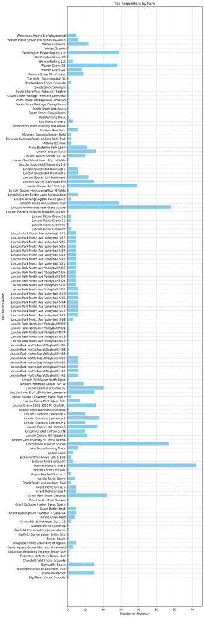

```python
import matplotlib.pyplot as plt
top_requestors_by_parks_df = top_requestors_by_parks.reset_index(name='Count')
plt.figure(figsize=(10, 30)) # Adjust the figure size as needed
plt.barh(top_requestors_by_parks_df['park_facility_name'],top_requestors_by_parks_df['Count'], color='skyblue')
plt.xlabel('Number of Requests')
plt.ylabel('Park Facility Name')
plt.title('Top Requestors by Park')
plt.grid(True, linestyle='--', alpha=0.6) # Optional: Adds a grid for easiervalue reading
plt.tight_layout() # Adjust layout to prevent label cutoff
plt.show()
```

Here we see that the parks are actually subdivided into smaller areas some being more popular than others. For example we see that the Horner Picnic Grove 8 is much more requested than the entire park combined. Certain areas are also more popular like athletic areas, historical landmarks, and recreational spaces like picnic areas.

in this next plot we will be looking at the top requestors by park dataset again. We will reset the index to facilitate sorting and filtering to only select the top 10 requested parks. We chose a horizontal bar chart for the best readability

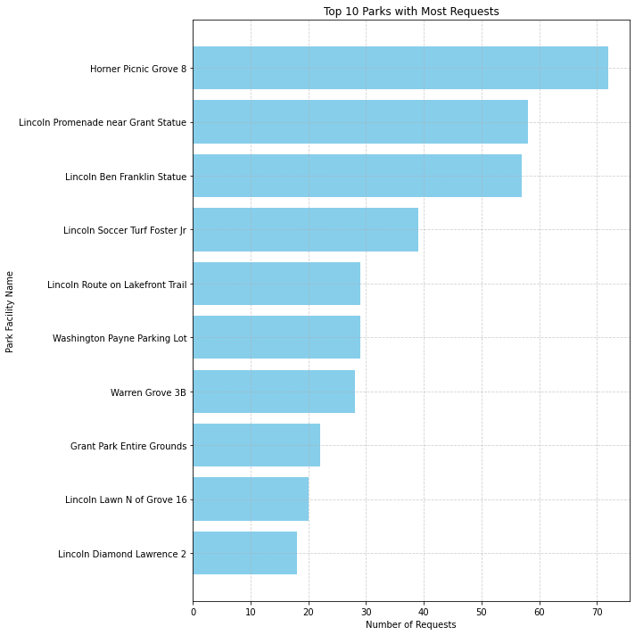

```python
top_requestors_by_parks_df = top_requestors_by_parks.reset_index(name='Count')
top_requestors_by_parks_df = top_requestors_by_parks_df.sort_values('Count',ascending=False).head(10)
plt.figure(figsize=(10, 10)) # Adjust the figure size appropriately
plt.barh(top_requestors_by_parks_df['park_facility_name'],top_requestors_by_parks_df['Count'], color='skyblue')
plt.xlabel('Number of Requests')
plt.ylabel('Park Facility Name')
plt.title('Top 10 Parks with Most Requests')
plt.gca().invert_yaxis() # Invert y-axis to display the highest value on top
plt.grid(True, linestyle='--', alpha=0.6) # Optional: Adds a grid for easier␣value reading
plt.tight_layout() # Adjust layout to prevent label cutoff
plt.show()
```

This plot will be using the top requestor by event and org dataframe.Since the series is multi-indexed (event_type, organization, requestor), we will reset the index to make plotting easier. We will look at only the unique event types and organizations.

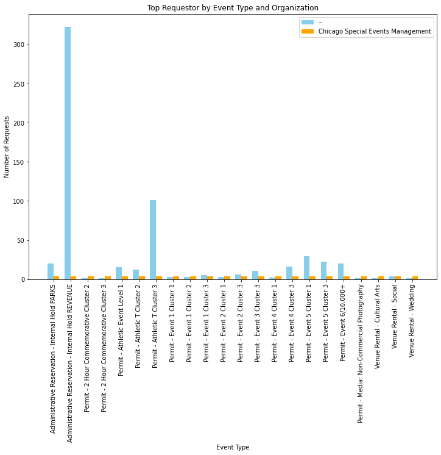

```python
import numpy as np
top_requestor_by_event_and_org_df = top_requestor_by_event_and_org.reset_index(name='Count')
event_types = top_requestor_by_event_and_org_df['event_type'].unique()
organizations = top_requestor_by_event_and_org_df['organization'].unique()
# Create a list of colors for each organization
colors = ['skyblue', 'orange', 'green', 'red', 'purple', 'brown', 'pink','gray']
# Plotting the grouped bar chart
bar_width = 0.35 # Width of each bar
index = np.arange(len(event_types)) # Index for x-axis ticks
plt.figure(figsize=(12, 8))
# Plot each organization's count for each event type
for i, org in enumerate(organizations):
    org_data = top_requestor_by_event_and_org_df[top_requestor_by_event_and_org_df['organization']==org]
    counts = org_data['Count']
    plt.bar(index + i * bar_width, counts, bar_width, color=colors[i],label=org)
plt.xlabel('Event Type')
plt.ylabel('Number of Requests')
plt.title('Top Requestor by Event Type and Organization')
plt.xticks(index + bar_width / 2, event_types, rotation=90) # Label each event type on x-axis
plt.legend()
```

Here we will create a copy of the original datafram for EDA. We have converted the reservation start data and end date to the datetime form. Additionally we handled missing values by filling with them a placeholder(-1) so that instead of dropping the values we just filter them out.

```python
import requests
url = 'https://data.cityofchicago.org/resource/pk66-w54g.json?$limit=125000'
r = requests.get(url)
print(f"Status code: {r.status_code}")
response_dict = r.json()
import pandas as pd
data = pd.DataFrame(response_dict)
data_copy = data.copy()
data_copy.head()
data_copy['reservation_start_date'] = pd.to_datetime(data_copy['reservation_start_date'])
data_copy['reservation_end_date'] = pd.to_datetime(data_copy['reservation_end_date'])
data_copy['reservation_start_date']
data_copy['reservation_end_date']
## Handling missing values
data_copy['park_number'] = data_copy['park_number'].fillna(-1)
print(data_copy['park_number'] == -1)

### Events per year
data_copy['Year'] = data_copy['reservation_start_date'].dt.year
events_per_year = data_copy['Year'].value_counts().sort_index()
data_copy['event_type'] = data_copy['event_type'].replace({'Permit - Event 6/10,000+':'Event 6'})
data_copy['event_type'] = data_copy['event_type'].replace({'Permit - Festival/Performance/12,001+ Event':'Festival/Performance Event'})
data_copy['event_type'] = data_copy['event_type'].replace({'Permit - Parking Lot Rental':'Parking Lot Rental Permit'})
data_copy['event_type'] = data_copy['event_type'].replace({'Permit - Promotions':'Promotional Event'})
mappings = {
'Administrative Reservation':'Administrative Reservation',
'Commemorative':'Commemorative',
'Athletic':'Athletic',
'Corporate Event':'Corporate Event',
'Media':'Media',
'Picnic':'Picnic',
'Venue Rental':'Venue Rental',
'Event 1 Cluster':'Event 1',
'Event 2 Cluster':'Event 2',
'Event 3 Cluster':'Event 3',
'Event 4 Cluster':'Event 4',
'Event 5 Cluster':'Event 5'
}
def categorize_event(event_description):
    for key,values in mappings.items():
        if key in event_description:
            return values
    return event_description
data_copy['Event Type Category'] = data_copy['event_type'].apply(categorize_event)
print(data_copy['Event Type Category'].unique())
```

```
Status code: 200
0         False
1         False
2         False
3         False
4         False
          ...
123193    False
123194    False
123195    False
123196    False
123197    False
Name: park_number, Length: 123198, dtype: bool
['Administrative Reservation' 'Athletic' 'Venue Rental' 'Event 3'
 'Event 2' 'Event 4' 'Event 5' 'Event 1' 'Event 6' 'Commemorative' 'Media'
 'Festival/Performance Event' 'Promotional Event' 'Picnic'
 'Corporate Event' 'Parking Lot Rental Permit']
```

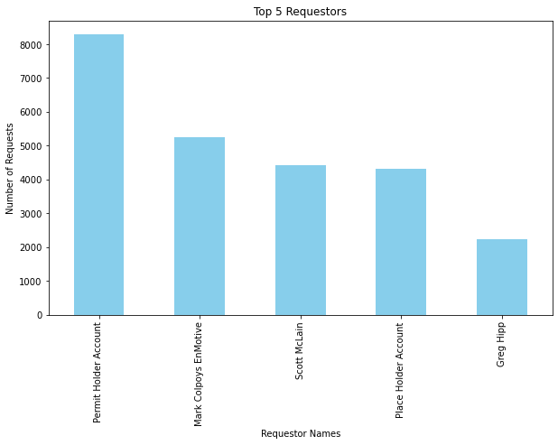

```python
requestor_counts = data_copy['requestor_'].value_counts().nlargest(5)
plt.figure(figsize=(10,6))
requestor_counts.plot(kind='bar', color='skyblue')
plt.xlabel('Requestor Names')
plt.ylabel('Number of Requests')
plt.title('Top 5 Requestors')
plt.show()
```

Displaying a bar chart showing the number of events conducted over the years

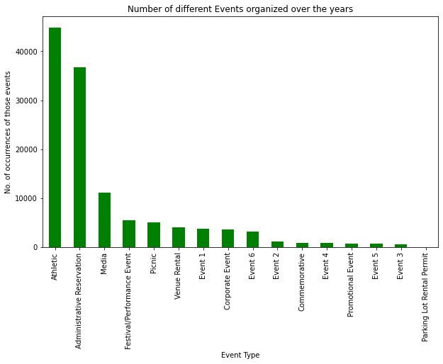

```python
event_counts = data_copy['Event Type Category'].value_counts()
plt.figure(figsize=(10,6))
event_counts.plot(kind='bar', color='green')
plt.xlabel('Event Type')
plt.ylabel('No. of occurrences of those events')
plt.title('Number of different Events organized over the years')
plt.show()
```

```python
#Renaming the columns to avoid duplications
mappings = {
'Approved':'Approved',
'Completed':'Approved',
'Issued':'Approved'
}
def status_change(permit_status):
    for key,values in mappings.items():
        if key in permit_status:
            return values
    return permit_status
data_copy['permit_status'] = data_copy['permit_status'].apply(status_change)
print(data_copy['permit_status'].unique())
```

```
['Tentative' 'Approved' 'On Hold' 'Waiting Decision' 'Stage Denied']
```

### Trend Analysis

Line chart shows the trend of the number of events that happened each year considering only the events with an 'Approved' permit status.

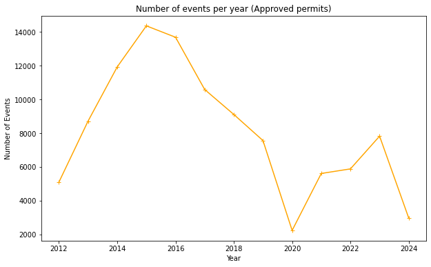

```python
approved_events = data_copy[data_copy['permit_status'] == 'Approved']
approved_events['Year'] = pd.to_datetime(approved_events['reservation_start_date']).dt.year
events_per_year = approved_events.groupby('Year')['Event Type Category'].count()
plt.figure(figsize=(10,6))
events_per_year.plot(kind='line', marker='+', color='orange')
plt.xlabel('Year')
plt.ylabel('Number of Events')
plt.title('Number of events per year (Approved permits)')
plt.show()
```

We created a function to categorize the months into seasons.

```python
import seaborn as sns

data_copy['Month'] = data_copy['reservation_start_date'].dt.month

# Function to categorize months into seasons
def get_season(month):
    if month in [12, 1, 2]:
        return 'Winter'
    elif month in [3, 4, 5]:
        return 'Spring'
    elif month in [6, 7, 8]:
        return 'Summer'
    elif month in [9, 10, 11]:
        return 'Fall'
data_copy['Season'] = data_copy['Month'].apply(get_season)
```

Aggregate data to find the number of reservations per park per season

```python
heatmap_data = data_copy.pivot_table(index='park_number', columns='Season',values='reservation_start_date', aggfunc='count', fill_value=0)
# plt.figure(figsize=(10, 8))
# sns.heatmap(heatmap_data, annot=True, fmt="d", cmap='coolwarm', linewidths=.5)
# plt.title('Reservations per Park by Season')
# plt.xlabel('Season')
# plt.ylabel('Park Number')
# plt.show()
# Rough plot to understand distribution of data
```

This heat map will look at the top 10 parks with the most reservations. We used a grey gradient to represent low to medium and red for high

Here we will aggregate data to find the number of reservations per park per season.After we will find the top 10 parks with the most reservations and filter the original heatmap to only include these parks.

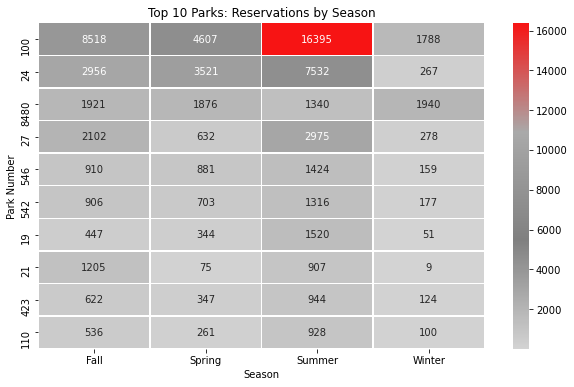

```python
import matplotlib.colors as mcolors
data_copy['Month'] = data_copy['reservation_start_date'].dt.month
# Function to categorize months into seasons
def get_season(month):
    if month in [12, 1, 2]:
        return 'Winter'
    elif month in [3, 4, 5]:
        return 'Spring'
    elif month in [6, 7, 8]:
        return 'Summer'
    elif month in [9, 10, 11]:
        return 'Fall'
data_copy['Season'] = data_copy['Month'].apply(get_season)
heatmap_data = data_copy.pivot_table(index='park_number', columns='Season',values='reservation_start_date', aggfunc='count', fill_value=0)
total_reservations_per_park = data_copy.groupby('park_number')['reservation_start_date'].count()
top_parks = total_reservations_per_park.nlargest(10).index
filtered_heatmap_data = heatmap_data.loc[top_parks]

colors = ["lightgrey", "grey", "darkgrey", "#f71414"]
cmap = mcolors.LinearSegmentedColormap.from_list("custom_red_grey", colors,N=256)

plt.figure(figsize=(10, 6))
sns.heatmap(filtered_heatmap_data, annot=True, fmt="d", cmap=cmap, linewidths=.5)
plt.title('Top 10 Parks: Reservations by Season')
plt.xlabel('Season')
plt.ylabel('Park Number')
plt.show()
```

We are sorting the reservations by season and then creating a pie chart

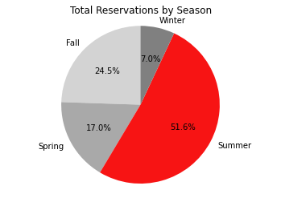

```python
import matplotlib.pyplot as plt
import matplotlib.colors as mcolors

season_data = data_copy.groupby('Season')['reservation_start_date'].count()
colors = ["lightgrey", "darkgrey", "#F71414", "grey"]
cmap = mcolors.LinearSegmentedColormap.from_list("custom_red_grey", colors, N=256)

fig, ax = plt.subplots()
ax.pie(season_data, labels=season_data.index, autopct='%1.1f%%', startangle=90, colors=colors)
ax.axis('equal')  # Equal aspect ratio ensures that pie is drawn as a circle.

plt.title('Total Reservations by Season')
plt.show()
```

Same pie chart except in donut form

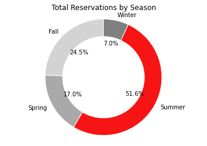

```python
season_data = data_copy.groupby('Season')['reservation_start_date'].count()
colors = ["lightgrey", "darkgrey", "#f71414", "grey"]
cmap = mcolors.LinearSegmentedColormap.from_list("custom_red_grey", colors,N=256)
fig, ax = plt.subplots()
outer_circle = plt.pie(season_data, labels=season_data.index, autopct='%1.1f%%', startangle=90, colors=colors,wedgeprops=dict(width=0.3, edgecolor='w'))

inner_circle = plt.pie([1], radius=0.5, colors='white') # Draw a white circle␣at the center

plt.axis('equal')
plt.title('Total Reservations by Season')
plt.show()
```

```python
top_parks = data_copy['park_number'].value_counts().nlargest(5).index
top_parks_data = data_copy[data_copy['park_number'].isin(top_parks)]
top_requestors = top_parks_data.groupby(['park_number', 'requestor_']).size().reset_index(name='counts')
top_requestors = top_requestors.sort_values(by=['park_number', 'counts'],ascending=[True, False])
```

```python
top_requestors_by_park = top_parks_data.groupby(['park_number', 'requestor_']).size().reset_index(name='counts')
total_reservations_by_requestor = top_requestors_by_park.groupby('requestor_').sum('counts').nlargest(10, 'counts')
top_requestors_filtered = top_requestors_by_park[top_requestors_by_park['requestor_'].isin(total_reservations_by_requestor.index)]
top_requestors_filtered = top_requestors_filtered.sort_values(by=['counts'],ascending=False)
```

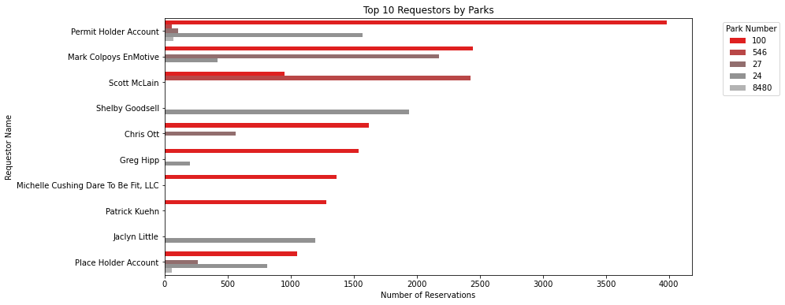

```python
colors = ["red", "gray", "lightgray"]
cmap = mcolors.LinearSegmentedColormap.from_list("custom_red_grey", colors,N=100)
plt.figure(figsize=(12, 6))
sns.barplot(x='counts', y='requestor_', hue='park_number',data=top_requestors_filtered, dodge=0.01,
palette=[cmap(i / float(len(top_parks))) for i in range(len(top_parks))])

plt.legend(title='Park Number', bbox_to_anchor=(1.05, 1), loc='upper left')
plt.title('Top 10 Requestors by Parks')
plt.xlabel('Number of Reservations')
plt.ylabel('Requestor Name')
plt.show()
```

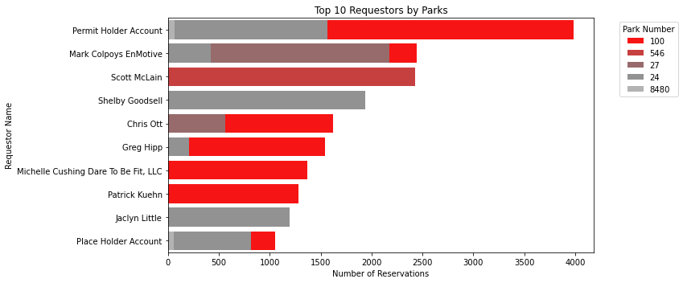

```python
colors = ["#f71414", "gray", "lightgray"]
cmap = mcolors.LinearSegmentedColormap.from_list("custom_red_grey", colors, N=100)
bar_width = 0.6
plt.figure(figsize=(12, 5))
sns.barplot(x='counts', y='requestor_', hue='park_number',data=top_requestors_filtered, dodge=False,
palette=[cmap(i / float(len(top_parks))) for i in range(len(top_parks))],
linewidth=1, saturation=1, alpha=1, ci=None,
estimator=sum, orient='h', capsize=0, errwidth=0)

plt.legend(title='Park Number', bbox_to_anchor=(1.05, 1), loc='upper left')
plt.title('Top 10 Requestors by Parks')
plt.xlabel('Number of Reservations')
plt.ylabel('Requestor Name')
plt.tight_layout()
plt.show()
```

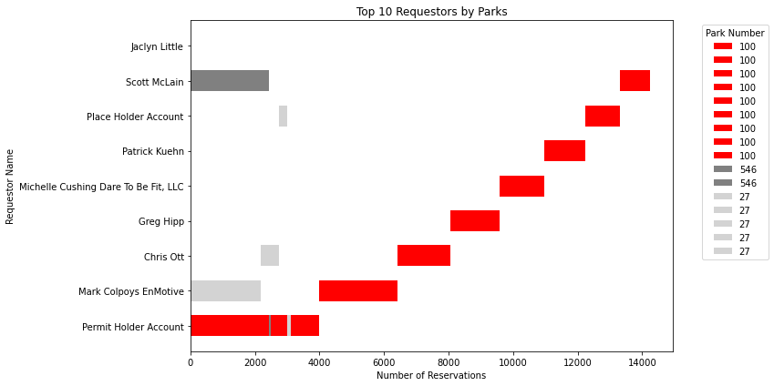

```python
colors = ["red", "gray", "lightgray"]
cmap = sns.color_palette(colors)
bar_width = 0.6
plt.figure(figsize=(12, 6))
ax = plt.gca()
for park_num, color in zip(top_requestors_filtered['park_number'].unique(),cmap):
    data_park = top_requestors_filtered[top_requestors_filtered['park_number'] == park_num]
    bottom = np.zeros(len(data_park['requestor_']))
    for requestor in data_park['requestor_'].unique():
        data_requestor = data_park[data_park['requestor_'] == requestor]
        ax.barh(data_requestor['requestor_'], data_requestor['counts'],color=color, label=park_num,left=bottom, height=bar_width)
        bottom += data_requestor['counts'].values
plt.legend(title='Park Number', bbox_to_anchor=(1.05, 1), loc='upper left')
plt.title('Top 10 Requestors by Parks')
plt.xlabel('Number of Reservations')
plt.ylabel('Requestor Name')
plt.tight_layout()
plt.show()
```

# Part 2: Final Dashboard

### Step 1: Importing necessary libraries

```python
import pandas as pd
import requests
import matplotlib.pyplot as plt
import seaborn as sns
from bqplot import pyplot as bq_plt, LinearScale, Axis, Lines, Figure, OrdinalScale, Scatter, Tooltip
from ipywidgets import Dropdown, Button, HBox, VBox, Output, Layout, Image, Label, GridBox, HTML
from IPython.display import display
import matplotlib.colors as mcolors
```

## Step 2: Load the data

#### Function to fetch and preprocess data

```python
url = 'https://data.cityofchicago.org/resource/pk66-w54g.json?$limit=125000'
r = requests.get(url)
response_dict = r.json()

if r.status_code != 200:
    df = pd.read_csv("https://raw.githubusercontent.com/LakshmiPriyaDiwakar2706/IS445-Final-Proj-Part-1/main/Chicago_Park_District_-_Event_Permits_20240411.csv")
else:
    df = pd.DataFrame(response_dict)
```

## Step 3: Preprocessing the data

```python
data_copy = df.copy()
data_copy.head()
data_copy['reservation_start_date'] = pd.to_datetime(data_copy['reservation_start_date'])
data_copy['reservation_end_date'] = pd.to_datetime(data_copy['reservation_end_date'])
data_copy['reservation_start_date']
data_copy['reservation_end_date']
## Handling missing values
data_copy['park_number'] = data_copy['park_number'].fillna(-1)


### Events per year
data_copy['Year'] = data_copy['reservation_start_date'].dt.year
events_per_year = data_copy['Year'].value_counts().sort_index()
data_copy['event_type'] = data_copy['event_type'].replace({'Permit - Event 6/10,000+':'Event 6'})
data_copy['event_type'] = data_copy['event_type'].replace({'Permit - Festival/Performance/12,001+ Event':'Festival/Performance Event'})
data_copy['event_type'] = data_copy['event_type'].replace({'Permit - Parking Lot Rental':'Parking Lot Rental Permit'})
data_copy['event_type'] = data_copy['event_type'].replace({'Permit - Promotions':'Promotional Event'})
mappings = {
'Administrative Reservation':'Administrative Reservation',
'Commemorative':'Commemorative',
'Athletic':'Athletic',
'Corporate Event':'Corporate Event',
'Media':'Media',
'Picnic':'Picnic',
'Venue Rental':'Venue Rental',
'Event 1 Cluster':'Event 1',
'Event 2 Cluster':'Event 2',
'Event 3 Cluster':'Event 3',
'Event 4 Cluster':'Event 4',
'Event 5 Cluster':'Event 5'
}
def categorize_event(event_description):
    for key,values in mappings.items():
        if key in event_description:
            return values
    return event_description
data_copy['Event Type Category'] = data_copy['event_type'].apply(categorize_event)


mappings = {
'Approved':'Approved',
'Completed':'Approved',
'Issued':'Approved'
}
def status_change(permit_status):
    for key,values in mappings.items():
        if key in permit_status:
            return values
    return permit_status
data_copy['permit_status'] = data_copy['permit_status'].apply(status_change)
```

#### Define CSS styles for bqplot

```python
bq_plt.style = {'title-font-size': '20px', 'axis-label-font-size': '15px', 'title-align': 'center'}
```

```python
approved_events = data_copy[data_copy['permit_status'] == 'Approved'].copy()
approved_events['Year'] = pd.to_datetime(approved_events['reservation_start_date']).dt.year
approved_events['Month'] = pd.to_datetime(approved_events['reservation_start_date']).dt.month
approved_events['Month_Name'] = pd.to_datetime(approved_events['reservation_start_date']).dt.strftime('%b')

# Function to categorize months into seasons
def get_season(month):
    if month in [12, 1, 2]:
        return 'Winter'
    elif month in [3, 4, 5]:
        return 'Spring'
    elif month in [6, 7, 8]:
        return 'Summer'
    elif month in [9, 10, 11]:
        return 'Fall'

approved_events['Season'] = approved_events['Month'].apply(get_season)
heatmap_data = approved_events.pivot_table(index='park_number', columns='Season', values='reservation_start_date', aggfunc='count', fill_value=0)
```

## Step 4: Line chart for total reseravtions trend

```python
line_chart_output = Output()
```

#### Creating scales for the bqplot

```python
x_sc = OrdinalScale()
y_sc = LinearScale()
```

#### Creating the line and scatter plot for year data

```python
line = Lines(scales={'x': x_sc, 'y': y_sc}, colors=['#f71414'])
scatter = Scatter(scales={'x': x_sc, 'y': y_sc}, colors=['#f71414'],
                  tooltip=Tooltip(fields=['x', 'y'], labels=['Year', 'Number of Events']), unhovered_style={'opacity': 0.5})
```

```python
x_ax = Axis(label='Year', scale=x_sc)
y_ax = Axis(label='Number of Events', scale=y_sc, orientation='vertical')

fig = Figure(marks=[line, scatter], axes=[x_ax, y_ax], title='Number of Events per Year (Approved Permits)')
```

```python
def update_line_chart(year):
    # Resetting axes scales for consistent updates
    global x_sc, x_ax
    if year != 'All Years':
        monthly_data = approved_events[approved_events['Year'] == int(year)].groupby('Month_Name')['reservation_start_date'].count().reindex(['Jan', 'Feb', 'Mar', 'Apr', 'May', 'Jun', 'Jul', 'Aug', 'Sep', 'Oct', 'Nov', 'Dec'], fill_value=0)
    else:
        yearly_data = approved_events.groupby('Year')['reservation_start_date'].count()

    with line_chart_output:
        line_chart_output.clear_output(wait=True)
        if year != 'All Years':
            line.x = monthly_data.index
            line.y = monthly_data.values
            scatter.x = monthly_data.index
            scatter.y = monthly_data.values
            x_ax.label = 'Month'
        else:
            line.x = yearly_data.index
            line.y = yearly_data.values
            scatter.x = yearly_data.index
            scatter.y = yearly_data.values
            x_ax.label = 'Year'

        x_sc = OrdinalScale()
        fig.axes = [x_ax, y_ax]
#         plt.figure(figsize=(5, 3))
        display(fig)
```

## Step 5: Heatmap for Top 10 Parks: Reservations by Season

#### Output widget for the heatmap

```python
heatmap_output = Output()
```

#### Update Heatmap Function

```python
def update_heatmap(year):
    # Filtering the data for the selected year or use all data if 'All Years' is selected
    filtered_data = approved_events[approved_events['Year'] == int(year)] if year != 'All Years' else approved_events

    # Creating a pivot table for the heatmap data
    heatmap_data = filtered_data.pivot_table(index='park_number', columns='Season', values='reservation_start_date', aggfunc='count', fill_value=0)

    # Calculating the total reservations for each park and get the top 10 parks
    total_reservations = heatmap_data.sum(axis=1).nlargest(10)
    top_parks = total_reservations.index

    # Filtering the heatmap data to include only the top 10 parks
    heatmap_data = heatmap_data.loc[top_parks]

    # Ensuring you have a dictionary or a way to map park numbers to names
    # If 'park_facility_name' is a column in 'filtered_data', create a mapping dictionary
    park_names = pd.Series(filtered_data['park_facility_name'].values, index=filtered_data['park_number']).to_dict()

    # Replacing park numbers with names in the index of heatmap data
    heatmap_data.index = heatmap_data.index.map(lambda x: park_names.get(x, 'Unknown'))

    with heatmap_output:
        heatmap_output.clear_output(wait=True)
        plt.figure(figsize=(10, 6))
        ax = sns.heatmap(heatmap_data, annot=True, fmt="d", cmap="coolwarm")
        plt.title('Top 10 Parks: Reservations by Season')
        plt.xlabel('Season')
        plt.ylabel('Park Name')
        ax.set_yticklabels(ax.get_yticklabels(), rotation=0)  # Make sure park names are readable
        plt.show()
```

## Step 6: Bar chart for Top 10 Requestors with Park Number

```python
bar_chart_output = Output()
```

```python
def update_bar_chart(year):
    if year != 'All Years':
        filtered_data = approved_events[approved_events['Year'] == int(year)]
    else:
        filtered_data = approved_events
    top_parks = filtered_data['park_number'].value_counts().nlargest(5).index
    top_parks_data = filtered_data[filtered_data['park_number'].isin(top_parks)]
    top_requestors = top_parks_data.groupby(['park_number', 'requestor_']).size().reset_index(name='counts')
    top_requestors = top_requestors.sort_values(by=['park_number', 'counts'],ascending=[True, False])
    top_requestors_by_park = top_parks_data.groupby(['park_number', 'requestor_']).size().reset_index(name='counts')
    total_reservations_by_requestor = top_requestors_by_park.groupby('requestor_').sum('counts').nlargest(10, 'counts')
    top_requestors_filtered = top_requestors_by_park[top_requestors_by_park['requestor_'].isin(total_reservations_by_requestor.index)]
    top_requestors_filtered = top_requestors_filtered.sort_values(by=['counts'],ascending=False)


    with bar_output:
        bar_output.clear_output(wait=True)
        colors = ["#f71414", "gray", "lightgray"]
        cmap = mcolors.LinearSegmentedColormap.from_list("custom_red_grey", colors, N=100)
        plt.figure(figsize=(10, 4))
        sns.barplot(x='counts', y='requestor_', hue='park_number', data=top_requestors_filtered, dodge=False,
                    palette=[cmap(i / float(len(top_parks))) for i in range(len(top_parks))],
                    linewidth=1, saturation=1, alpha=1, ci=None, orient='h', capsize=0, errwidth=0)
        plt.legend(title='Park Number', bbox_to_anchor=(1.05, 1), loc='upper left')
        plt.title('Top 10 Requestors with Park Number (Approved Events Only)')
        plt.xlabel('Number of Reservations')
        plt.ylabel('Requestor Name')
        plt.tight_layout()
        plt.show()
```

## Step 7: Donut Chart to show reservations by Season

```python
donut_chart_output = Output()
```

```python
def update_donut_chart(year):
    if year != 'All Years':
        filtered_data = approved_events[approved_events['Year'] == int(year)]
    else:
        filtered_data = approved_events

    season_data = filtered_data.groupby('Season')['reservation_start_date'].count()
    colors = ["lightgrey", "darkgrey", "#f71414", "grey"]
    cmap = mcolors.LinearSegmentedColormap.from_list("custom_red_grey", colors, N=256)

    with donut_output:
        donut_output.clear_output(wait=True)
        # Adjust figsize to desired pixel dimensions divided by DPI (assuming 100 dpi)
#         fig, ax = plt.subplots(figsize=(10, 10))  # 200px/100dpi by 100px/100dpi
        outer_circle = ax.pie(season_data, labels=season_data.index, autopct='%1.1f%%', startangle=90, colors=colors, wedgeprops=dict(width=0.2, edgecolor='w'))
        inner_circle = ax.pie([1], radius=0.3, colors=['white'])

        ax.set_aspect('equal')
        ax.set_title('Total Reservations by Season')
        plt.show()
```

```python
# bar_chart_2_output = Output()
```

```python
# def update_parks_requests_bar_chart(year):
#     if year != 'All Years':
#         filtered_data = approved_events[approved_events['Year'] == int(year)]
#     else:
#         filtered_data = approved_events
#     top_requestors_by_parks_df = top_requestors_by_parks.reset_index(name='Count')
#     top_requestors_by_parks_df = top_requestors_by_parks_df.sort_values('Count',ascending=False).head(10)
#     with bar_chart_2_output:
#         bar_chart_2_output.clear_output(wait=True)
#         plt.figure(figsize=(10, 4)) # Adjust the figure size appropriately
#         plt.barh(top_requestors_by_parks_df['park_facility_name'],top_requestors_by_parks_df['Count'], color='darkgrey')
#         plt.xlabel('Number of Requests')
#         plt.ylabel('Park Facility Name')
#         plt.title('Top 10 Parks with Most Requests')
#         plt.gca().invert_yaxis() # Invert y-axis to display the highest value on top
#         plt.grid(True, linestyle='--', alpha=0.6) # Optional: Adds a grid for easier␣value reading
#         plt.tight_layout() # Adjust layout to prevent label cutoff
#         plt.show()
```

## Step 8: Define Functions to Update Plots

```python
def update_plots(year):
    update_heatmap(year)
    update_line_chart(year)
    update_donut_chart(year)
    update_bar_chart(year)
    update_parks_requests_bar_chart(year)
```

```python
heatmap_output = Output()
donut_chart_output = Output()
bar_chart_output = Output()
line_chart_output = Output()
bar_chart_2_output = Output()
```

## Step 9: Connect Widgets with Actions

```python
def refresh_dashboard(_):
    global data_copy
    data_copy = get_data()  # Refresh data from the source
    print("Data has been refreshed.")
    year_dropdown.value = 'All Years'
    update_plots('All Years')
```

#### Setup widgets

```python
year_dropdown = Dropdown(options=['All Years'] + sorted(data_copy['Year'].unique().astype(str).tolist()), description='Select Year')
year_dropdown.observe(lambda change: update_plots(change.new if change.new else 'All Years'), names='value')

refresh_button = Button(description="Refresh", button_style='danger', icon='refresh')
refresh_button.on_click(refresh_dashboard)
```

## Step 10: Adding an image

```python
file_path = 'Park.png'  # Adjust path if necessary
with open(file_path, "rb") as f:
    image_data = f.read()
park_image = Image(value=image_data, format='png', width=20, height=20)
```

## Step 11: Initialize Dashboard

```python
update_plots('All Years')
```

```python
# Grid layout for dashboard
dashboard = GridBox(children=[control_box, fig, heatmap_output, donut_output, bar_output],
                     layout=Layout(
                         width='100%',
                         grid_template_rows='auto auto auto',
                         grid_template_columns='50% 50%',
                         grid_template_areas='''
                         "header header"
                         "left right"
                         "lower lower"
                         '''
                     ))
# Assign grid areas
control_box.layout.grid_area = 'header'
fig.layout.grid_area = 'left'
line_chart_output.layout.grid_area = 'left'
heatmap_output.layout.grid_area = 'right'
donut_chart_output.layout.grid_area = 'lower right'
bar_chart_output.layout.grid_area = 'lower left'

# Display the dashboard
dashboard
```

```
GridBox(children=(HBox(children=(Dropdown(description='Select Year', index=8, options=('All Years', '2012', '2…
```

```python
# Adjust the layout of the GridBox
dashboard = GridBox(
    children=[
        control_box,   # Controls for the dashboard (refresh, dropdowns)
        park_image,    # Image widget displaying a park picture
        line_chart_output, # The line chart figure
        heatmap_output, # Output widget displaying the heatmap
        donut_chart_output, # Output widget displaying the donut chart
        bar_chart_output, # Output widget for the existing bar chart
        bar_chart_2_output # Output widget for the additional bar chart
    ],
    layout=Layout(
        width='100%',
        grid_template_rows='auto auto',  # Two rows
        grid_template_columns='20% 40% 40%', # Three columns, adjust as needed
        grid_template_areas='''
            "header header header"
            "image line_chart bar_chart_2"
            "donut_chart heatmap bar_chart"
            '''
    )
)

# Assign grid areas for layout
control_box.layout.grid_area = 'header'
park_image.layout.grid_area = 'image'
line_chart_output.layout.grid_area = 'line_chart'
heatmap_output.layout.grid_area = 'heatmap'
donut_chart_output.layout.grid_area = 'donut_chart'
bar_chart_output.layout.grid_area = 'bar_chart'
bar_chart_2_output.layout.grid_area = 'bar_chart_2'

# Additionally, set the individual elements to automatically adjust their sizes within their grid areas
for widget in [park_image, line_chart_output, heatmap_output, donut_chart_output, bar_chart_output, bar_chart_2_output]:
    widget.layout.width = '100%'
    widget.layout.height = '100%'  # Adjust heights as needed to match visual style

# Display the dashboard
display(dashboard)
```

```
GridBox(children=(HBox(children=(Dropdown(description='Select Year', index=8, options=('All Years', '2012', '2…
```

## Code:

- An interactive dashboard within your Workspace that helps an expert explore your dataset thoroughly.
- There should be a "dashboard" type aspect to this - i.e. a linked view exploring your dataset in an interactive way (like in Lab #4) with [bqplot](https://bqplot.github.io/bqplot/).
- Do not delete any cells, *just comment them out*. Show your work.